# Testing Means in R

Gabriel J. Odom, PhD, ThD

September 21, 2018

## Overview

While we are still interested ultimately in testing the *distribution* of a data sample, we can first test if the mean of the sample is equal to the population mean.

## Student’s $t$-Test

To do this, we employ the [Student’s $t$-test](https://en.wikipedia.org/wiki/Student%27s_t-test) for one sample. We first assume that the population can be reasonably approximated by a Normal distribution with mean $\mu_0$ and standard deviation $\sigma_0$. That is, wish to test the hypothesis
$$H_0: \mu = \mu_0;\quad H_A: \mu \ne \mu_0.$$
To test this hypothesis, we take a sample of data
$$X = (x_1, x_2, \ldots, x_n),$$
and we denote the sample mean as $\bar{x}$, sample standard deviation as $s$, and sample size as $n$. Given this sample, we test how unlikely it would be to see such a sample from the hypothesized distribution.

The testing algorithm is as follows:

1. Plot a histogram of the data to check normality.
2. Calculate the sample mean and sample standard deviation.
3. Find the test statistic with the formula
   $$t = \frac{\bar{x} - \mu}{s/\sqrt{n}}$$
4. Look up the [critical value](http://www.sjsu.edu/faculty/gerstman/StatPrimer/t-table.pdf) from the Student’s $t$ distribution based on $n - 1$ degrees of freedom and an appropriate Type-I error level (like $\alpha = 0.05$). Based on the alternative hypothesis ($H_A$), we are performing a two-tailed test, so the confidence level is $1 - \alpha/2$.
5. Compare the test statistic to the critical value to make a decision. If the absolute value of the test statistic is greater than the critical value, then you reject the null hypothesis ($H_0$).

## Coding the Test in `R`

Thankfully, there is a simple function to perform a Student’s $t$-test in `R`: `t.test()`. First, let’s draw a random sample. We are going to test the means for seven distributions, even distributions that are not even close to Normal! I’ll chose a $\chi^2$-distribution to go first. I’d like a sample of size 15, with a mean of 2 (so I need to set the $\nu$ parameter to 2).

```r
set.seed(1234)
xChiSq_ls <- list(
  dist   = "ChiSq",
  params = c(df = 2),
  sample = rchisq(n = 15, df = 2)
)
```

My first step is to plot a histogram of the data.

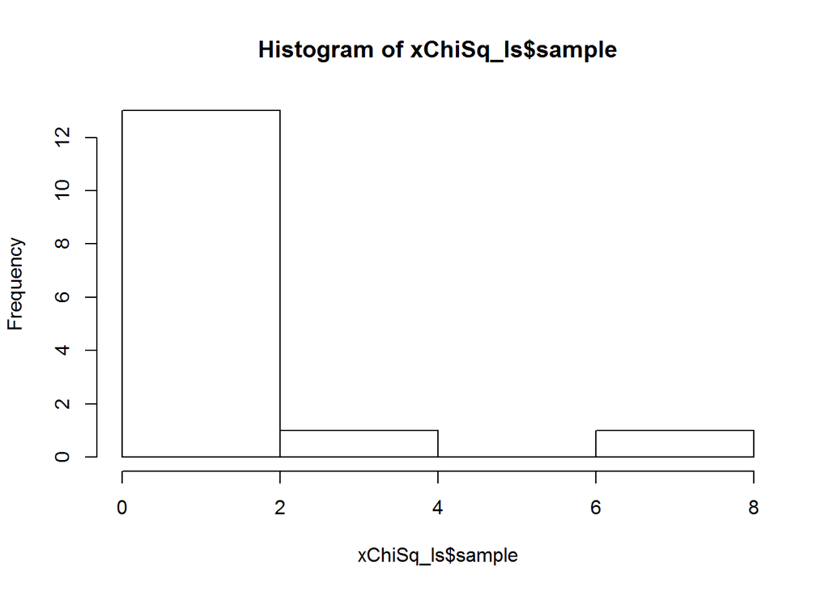

```r
hist(xChiSq_ls$sample)
```

Obviously this data doesn’t look normal, but we will continue ahead with the $t$-test for the sake of example alone.

The next step is to look up the [`t.test()` function](https://www.rdocumentation.org/packages/stats/versions/3.5.1/topics/t.test) to find the appropriate arguments.

```r
?t.test
```

We can see that we need to supply some values to these arguments or change the defaults for others:

- `x` will be our vector `sample` in the `xChiSq_ls` list.
- We aren’t testing that two vectors are equal, so we can leave the `y` argument alone.
- Based on the “not equal to” comparison of our alternative hypothesis ($H_A: \mu \ne \mu_0$), we will need to specify a two-tailed test: `alternative = "two.sided"`.
- We are testing that the mean, $\mu_0$ is equal to 2, so we need to specify that `mu = 2`.
- If we are comfortable with a Type-I error rate of 5%, we can leave the `conf.level` argument alone.

Based on all of these components, my call to the `t.test()` function will be

```r
ttest_out <- t.test(
  x = xChiSq_ls$sample,
  alternative = "two.sided",
  mu = xChiSq_ls$params
)
```

## Inspecting the Test Output

We need to extract some information from this test, such as the $p$-value and test statistic. We can first print the test output object we just created.

```r
ttest_out
```

```
##
##  One Sample t-test
##
## data:  xChiSq_ls$sample
## t = -1.5541, df = 14, p-value = 0.1425
## alternative hypothesis: true mean is not equal to 2
## 95 percent confidence interval:
##  0.2947048 2.2723325
## sample estimates:
## mean of x
##  1.283519
```

From this printed output, we can see that

1. The $p$-value is 0.1425.
2. The test statistic is -1.5541.

Because we need to save this information in our experiment list, we need to know how to extract this information from the `ttest_out` object. Notice that the Environment tab in the top right of RStudio tells us that the `ttest_out` object is a list. We can find the names of a list with the `names()` function. These are the names of the elements stored within the `ttest_out` object:

```r
names(ttest_out)
```

```
## [1] "statistic"   "parameter"   "p.value"     "conf.int"    "estimate"
## [6] "null.value"  "alternative" "method"      "data.name"
```

### The Test Statistic and $p$-Value

We see that there are two elements we are interested in: `"statistic"` and `"p.value"`. Let’s take a look at these.

```r
ttest_out$statistic
```

```
##         t
## -1.554084
```

```r
ttest_out$p.value
```

```
##        df
## 0.1424741
```

These are exactly what we’re looking for. However, we need one last piece of information: the critical value.

### The Critical Value

Based on Step 4 above, we can look up the critical value of a test with a 95% confidence level and 15 - 1 degrees of freedom in a table. Or, we can have `R` do it for us! Remember that we used the `rt()` function to generate *random* values from the Student’s $t$ distribution. We can use the `qt()` function to give us the *quantile* of the distribution based on the confidence level and degrees of freedom. Remember that a Type-I error of $\alpha = 0.05$ gives us a two-sided confidence quantile of 0.975 ($1 - \alpha/2$).

```r
critVal <- qt(0.975, df = 15 - 1)
```

## Making a Decision and Storing our Results in a List

Now that we have the test statistic and critical value, we can compare them to make a decision. Should we reject $H_0$?

```r
abs(ttest_out$statistic) > critVal
```

```
##     t
## FALSE
```

No, we should not. Also, notice that we could have made the same decision via the $p$-value:

```r
ttest_out$p.value < 0.05
```

```
##    df
## FALSE
```

Now we need to store all these components in our experment list.

```r
# p-value
xChiSq_ls$pVal <- ttest_out$p.value

# test statistic
xChiSq_ls$testStat <- ttest_out$statistic

# critical value
xChiSq_ls$critVal <- critVal

# decision
xChiSq_ls$decision <- "Fail to Reject the Hypothesis that the True Mean Equals 2"
```

Let’s take a look at our experiment:

```r
xChiSq_ls
```

```
## $dist
## [1] "ChiSq"
##
## $params
## df
##  2
##
## $sample
##  [1] 0.02145511 1.49399813 1.57265591 0.23375047 1.84371739 0.35235796
##  [7] 2.87428445 0.31343940 0.43900405 7.05514522 0.12651363 0.29429374
## [13] 1.19861920 0.42645167 1.00709343
##
## $pVal
##        df
## 0.1424741
##
## $testStat
##         t
## -1.554084
##
## $critVal
## [1] 2.144787
##
## $decision
## [1] "Fail to Reject the Hypothesis that the True Mean Equals 2"
```